# Data Example with Kidney Data

A, A, & R

06 June, 2017

```r
library(randomForest)
```

```r
library(rpart)
library(rpart.plot)
library(logspline)
```

```r
 aim2 <- function(dat,nreps=1,n.grid=20,mult=2,outvar="Y",prop.learning=0.5)
 {
   #Functions that go into penalized fitting method
   aim2.list <- list(eval=aim2.eval, split=aim2.split, init=aim2.init,
                     summary=aim2.summary, text=aim2.text)
   n <- nrow(dat)

   #Identify outcome variable   --- this is redundant with functions statement and should be changed
   which.outcome <- which(colnames(dat)==outvar)
   colnames(dat)[which.outcome] <- "outvar.aim2"

   #Split training set into learning and evaluation sets - now based on 50/50 split
   # later look at different alternatives
   nlearn <- round(prop.learning*n)
   neval <- n-nlearn
   samp <- sample(1:n,n,replace=FALSE)
   wlearn <- sort(samp[1:nlearn])
   weval <- sort(samp[(nlearn+1):n])
   learning.dat <- dat[wlearn,]
   evaluation.dat <- dat[weval,]

   #The lambdas chosen using a grid. Here, get values for variables based on root node
   fit.rf.learning <- randomForest(outvar.aim2 ~ .,data = learning.dat) # Fit RF with learning set
   predict.rf.evaluation <- predict(fit.rf.learning,newdata=evaluation.dat,
                                    predict.all=TRUE) #  $\widehat{Z}_{1i}$
   mean.evaluation <- mean(evaluation.dat$outvar.aim2) # $\mu_{Z_1}$
   var.evaluation <- var(evaluation.dat$outvar.aim2) # $\sigma^2_{Z_1}$
   zbarhat <- mean(predict.rf.evaluation$aggregate) # $ \bar{\hat{Z_1}}$

     # NOTE: this zbarhat means we are doing the
     # alternative shrinkage target in equation 9 not the original in 6

   var.z1s <-  apply(predict.rf.evaluation$individual,1,var) # $\sigma^2_{\hat{Z_1i}}$
   alphas <- 1/var.z1s # $\alpha_i$
   alphabar <- mean(alphas) # \bar{\alpha}$
   lambda <- var.evaluation/(neval*alphabar*(mean.evaluation-zbarhat)^2) #with-in node
                                                                         #choice of \lambda
   lambdas <- seq(0,mult*lambda,length.out=n.grid)  # list of possible lambdas
   n.lambdas <- length(lambdas) #length of list
   error.lambdas <- rep(0,length(lambdas))
   fits <- vector("list",n.lambdas)
   predictions <- vector("list",n.lambdas)
   #print("almost there")
   # To get the err(\lambda) - uncorrected - currently equation 11
   for(j in 1:n.lambdas)
     {
       #print(lambdas[j])
       current.fit <- rpart(outvar.aim2 ~ .,data = evaluation.dat,
                            parms=list(lambda=lambdas[j],
                            yhat=predict.rf.evaluation$aggregate,
                            alpha=alphas),method=aim2.list)
       xgroup <- rep(1:10, length = nrow(evaluation.dat))
       xfit <- xpred.rpart(current.fit,xgroup)
       xerror <- colMeans((xfit - evaluation.dat$outvar.aim2)^2)
       min.CP<-current.fit$cptable[which(xerror==min(xerror)),1][1]
       current.fit.pruned<-prune(current.fit,cp=min.CP)
       predicted.fit <- predict(object=current.fit.pruned,newdata=evaluation.dat)
       error.lambdas[j] <- sum((evaluation.dat$outvar.aim2-predicted.fit)^2)
       fits[[j]] <- current.fit.pruned
       predictions[[j]] <- predicted.fit
   }

   # To get the optimism for correcting the err(\lambda)
   optimism <- corrected.lambda(dat=evaluation.dat,lambdas=lambdas,
                                list.object=aim2.list,model=fit.rf.learning,
                                predicted.values=predict.rf.evaluation$aggregate,
                                alphas=alphas,n.boot=10)

   # err(\lambda) corrected
   Error.lambdas <- error.lambdas+optimism

   #return list of interesting variables.
   list(lambdas=lambdas,Error.lambdas=Error.lambdas,error.lambdas=error.lambdas,
        optimism=optimism,fits=fits,predictions=predictions,
        predicted.fit=predicted.fit,evaluation.dat=evaluation.dat)
 }
```

```r
corrected.lambda <- function(dat,lambdas,list.object,model,predicted.values,alphas,n.boot=10)
  {
    n1 <- nrow(dat)
    p <- ncol(dat)
    n.lambdas <- length(lambdas)
    cilambda <- matrix(0,n1,n.lambdas)
    boot.dat <- boot.residual <- matrix(NA,n1,n.boot)
    sigmahat <- sqrt(sum((dat$outvar.aim2-predicted.values)^2)/n1) #SD for \hat{\sigma^2_{Z_1-\bigM}}

    for(b in 1:n.boot) boot.dat[,b] <- rnorm(n1,mean=predicted.values,sd=sigmahat)#bootstrap samples
    boot.mean <- matrix(apply(boot.dat,1,mean))  # \bar{Z^*_{1i}}
    for(i in 1:nrow(boot.dat)) boot.residual[i,] <- boot.dat[i,]-boot.mean[i]
    for(b in 1:n.boot)
      {
        new.dat <- dat
        new.dat$outvar.aim2 <- boot.dat[,b]
        for(j in 1:n.lambdas)
          {
            final.fit <- rpart(outvar.aim2 ~ .,data = new.dat,
                               parms=list(lambda=lambdas[j],
                               yhat=predicted.values,alpha=alphas),
                               method=list.object)
            xgroup <- rep(1:10, length = nrow(new.dat))
            xfit <- xpred.rpart(final.fit,xgroup)
            xerror <- colMeans((xfit - new.dat$outvar.aim2)^2)
            min.CP<-final.fit$cptable[which(xerror==min(xerror)),1][1]
            final.fit.pruned<-prune(final.fit,cp=min.CP)

            bigMhat <- predict(object=final.fit.pruned,newdata=new.dat)
            cilambda[,j] <- cilambda[,j]+bigMhat*boot.residual[,b]
          }
      }
    cilambda <- cilambda/(n.boot-1)
    return(2*apply(cilambda,2,sum))
  }
```

```r
#y contains response Z_i, Zhat_i from RF, and alpha where alpha=1/var(zhat)

aim2.init <- function(y, offset, parms, wt)
{
  if (!is.null(offset)) y[,1] <- y[,1]-offset
  list(y=cbind(y,parms$yhat,parms$alpha),parms=parms, numy=3, numresp=1, summary=aim2.summary)
}

aim2.eval <- function(y, wt, parms)
{
  n <- length(y)/3
  lambda <- parms$lambda
  yhat <- y[,2]
  alphas <- y[,3]
  alphabar <- sum(alphas)/n
  y1 <- y[,1]
  r <- 1/(1+lambda*alphabar)
  zbar <- mean(y1)
  zbarhat <- sum(yhat*alphas)/sum(alphas)
  chat <- r*zbar+(1-r)*zbarhat
  rss <- sum((y1-chat)^2+lambda*alphas*(chat-yhat)^2)
  list(label=chat, deviance=rss)
}

aim2.split <- function(y, wt, x, parms, continuous)
  {
    n <- length(y[,1])
    y1 <- y[,1]
    yhat <- y[,2]
    alpha <- y[,3]
    lambda <- parms$lambda
    if (continuous)
      {
        if(is.null(lambda)) compute.lambda #Placeholder until I figure out how to compute lambda
        goodness <- direction <- double(n-1) #Allocate 0 vector
        y.cumsum <- cumsum(y1)
        y.left <- y.cumsum[-n]
        y.right <- y.cumsum[n]-y.left
        yhat.cumsum <- cumsum(yhat*alpha)
        yhat.left <- yhat.cumsum[-n]
        yhat.right <- yhat.cumsum[n]-yhat.left
        alpha.cumsum <- cumsum(alpha)
        alpha.left <- alpha.cumsum[-n]
        alpha.right <- alpha.cumsum[n]-alpha.left
        for(i in 1:(n-1))
          {
            zbar.left <- y.left[i]/i
            zbar.right <- y.right[i]/(n-i)
            zbarhat.left <- yhat.left[i]/alpha.left[i]
            zbarhat.right <- yhat.right[i]/alpha.right[i]
            alphabar.left <- alpha.left[i]/i
            alphabar.right <- alpha.right[i]/(n-i)
            r.left <- 1/(1+lambda*alphabar.left)
            r.right <- 1/(1+lambda*alphabar.right)
            chat.left <- r.left*zbar.left+(1-r.left)*zbarhat.left
            chat.right <- r.right*zbar.right+(1-r.right)*zbarhat.right

#            goodness[i] <- sum((y1-mean(y1))^2)
#                 - (sum((y1[1:i]-chat.left)^2 +
#                    lambda*alpha[1:i]*(yhat[1:i]-chat.left)^2) +
#                   sum((y1[(i+1):n]-chat.right)^2 +
#                  lambda*alpha[(i+1):n]*(yhat[(i+1):n]-chat.right)^2))
#           Do we need adjustment for missing values like in  vignette example?

            direction[i] <- sign(zbar.left-zbar.right)
            goodness.left <- sum((y1[1:i]-chat.left)^2 + lambda*alpha[1:i]*(yhat[1:i]-chat.left)^2)
            goodness.right <- sum((y1[(i+1):n]-chat.right)^2 +
                                    lambda*alpha[(i+1):n]*(yhat[(i+1):n]-chat.right)^2)
            tss <- sum((y1-mean(y1))^2)
            goodness[i] <- tss-goodness.left-goodness.right

          }
      } # this means we can only have x continuous - no categorical
#    goodness <- 1/goodness
    return(list(goodness=goodness, direction=direction))
  }

aim2.summary <- function(yval, dev, wt, ylevel, digits )
{
  paste(" mean=", format(signif(yval, digits)), ", MSE=" , format(signif(dev/wt, digits)), sep= '')
}

aim2.text <- function(yval, dev, wt, ylevel, digits, n, use.n )
{
  if(use.n) paste(formatg(yval,digits)," nn=", n,sep="")
  else paste(formatg(yval,digits))
}
```

## Example: data

For an example, we have the gen.data data. In the following block of text we read in the data, rename the columns, run the algorithm (via `aim2` function) and then plot the errors.

```r
############ Fill in data info ####################
dat <- read.csv("/Users/annettemolinaro/Box Sync/Projects/R01/Aim2/Data/covs.IHC.14genes.csv",as.is=TRUE)

#848 have events, 800 are censored.
dat3 <- dat2 <- dat[which(dat$dt==1),]

dat3$surg_to_last_fu <- sqrt(dat3$surg_to_last_fu)

dat4 <- dat3[,-which(colnames(dat3)=="rccdt"|colnames(dat3)=="dt")]
dat4$height[which(dat4$height=="")]<-0
dat4$height<-as.numeric(dat4$height)
dat4$height[which(dat4$height==0)]<-NA
table(dat$necrosis)
```

```
##
##   No  Yes
## 1260  388
```

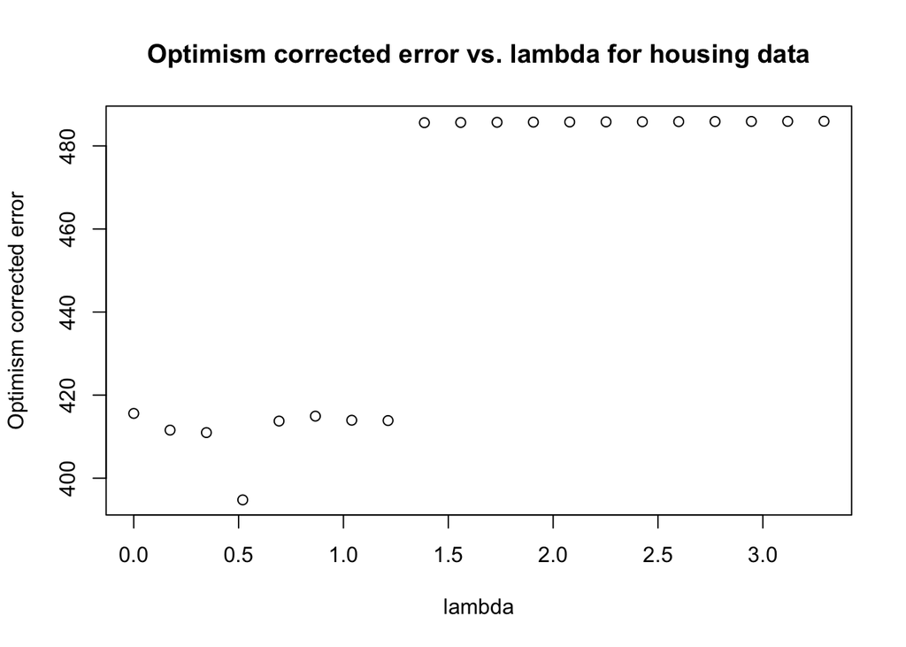

```r
dat4$necrosis<-as.numeric(as.factor(dat4$necrosis))
dat4$male<-as.numeric(as.factor(dat4$male))
#md.pattern(dat4)
library(mice)
dat.imput<-mice(dat4,m=5,maxit=5,method='pmm',seed=500,printFlag=FALSE)

dat.complete<-complete(dat.imput,1)
dat.complete$Study_ID_1<-NULL
dat.complete$mdev<-dat.complete$surg_to_last_fu
dat.complete$surg_to_last_fu<-NULL
#########################################################






set.seed(12345)
gen.data <- dat.complete

temp <- aim2(dat=gen.data,nreps=1,n.grid=20,mult=2,outvar="mdev",prop.learning=0.5)

  plot(temp$lambdas,temp$Error.lambdas,xlab="lambda",ylab="Optimism corrected error",
       main="Optimism corrected error vs. lambda for housing data")
```

According to this plot, we would select the lambda equal to $0.5197588$ is the one which minimizes the optimism corrected error. Using that lambda we get the following rpart tree:

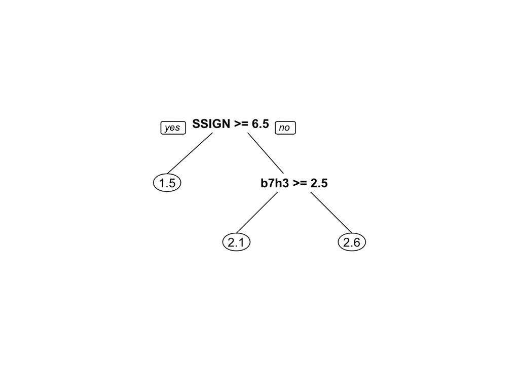

The resubstitution estimate of prediction error is $ 761.859$.

If we just ran a rpart tree:

```r
(justRpart<-rpart(mdev ~ .,data = gen.data)  )
```

```
## n= 848
##
## node), split, n, deviance, yval
##       * denotes terminal node
##
##   1) root 848 934.35660 2.254653
##     2) SSIGN>=6.5 207 144.40630 1.556813
##       4) Survivin.mm2>=49.35 63  29.09194 1.179116 *
##       5) Survivin.mm2< 49.35 144 102.39510 1.722056 *
##     3) SSIGN< 6.5 641 656.59220 2.480008
##       6) b7h3>=2.5 181 128.79620 2.083640 *
##       7) b7h3< 2.5 460 488.17020 2.635971
##        14) age_at_surg>=72.13005 175 153.45190 2.398763 *
##        15) age_at_surg< 72.13005 285 318.82520 2.781625
##          30) CAIX.pct.stain>=95 200 222.57750 2.619567
##            60) topo2.cells.per.mm2>=13.55 48  53.83407 2.128288 *
##            61) topo2.cells.per.mm2< 13.55 152 153.50000 2.774707
##             122) vhl.hscore< 155 47  44.28080 2.353790 *
##             123) vhl.hscore>=155 105  97.16483 2.963118
##               246) age_at_surg< 52.73101 7  10.03454 1.634416 *
##               247) age_at_surg>=52.73101 98  73.88941 3.058025 *
##          31) CAIX.pct.stain< 95 85  78.63613 3.162938
##            62) ezh2.pct>=10.15 17  16.88657 2.382384 *
##            63) ezh2.pct< 10.15 68  48.80269 3.358076 *
```

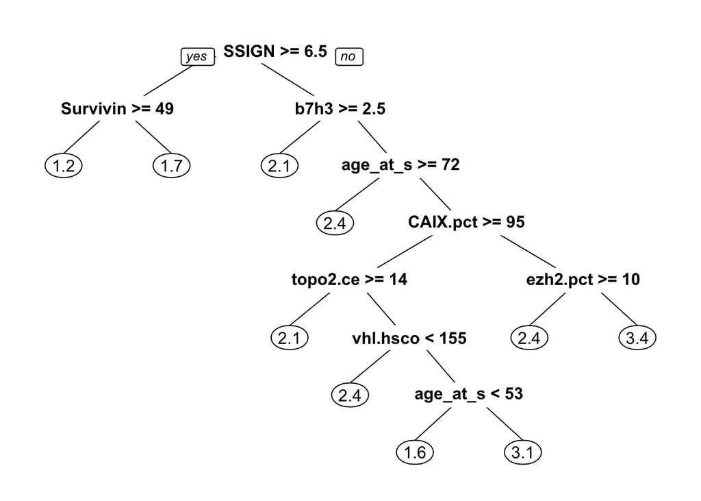

```r
#prp(justRpart)
min.CP<-justRpart$cptable[which(justRpart$cptable[,4]==min(justRpart$cptable[,4])),1]
justRpartpruned<-prune(justRpart,cp=min.CP)
prp(justRpartpruned)
```

```r
   rpart.test.dat.predicted.fit.resub<-predict(object=justRpartpruned,newdata=gen.data)
  rpart.error.test.dat.resub <- sum((gen.data$mdev-rpart.test.dat.predicted.fit.resub)^2)
```

With prediction error $661.463$

## Switching to Composite functions.

At the moment we have three composite functions - the original we worked on in DC, the “thirds” version Adam has worked on and Rob’s version which searches a grid and uses a logspline density for the bootstrap.

### DC Code

```r
composite.rpart=function(dat,n.grid=20,mult=2,outvar="Y",prop.learning=0.5)
{
  n <- nrow(dat)
  which.outcome <- which(colnames(dat)==outvar)
  colnames(dat)[which.outcome] <- "outvar.aim2"

  #Split into learning and evaluation sets
  nlearn <- round(prop.learning*n)
  neval <- n-nlearn
  samp <- sample(1:n,n,replace=FALSE)
  wlearn <- sort(samp[1:nlearn])
  weval <- sort(samp[(nlearn+1):n])
  learning.dat <- dat[wlearn,]
  evaluation.dat <- dat[weval,]

  fit.rf.learning <- randomForest(outvar.aim2 ~ .,data = learning.dat,ntree=1000) # Fit RF with learning set
  predict.rf.evaluation <- predict(fit.rf.learning,newdata=evaluation.dat,predict.all=TRUE) #  $\widehat{Z}_{1i}$
  mean.evaluation <- mean(evaluation.dat$outvar.aim2) # $\mu_{Z_1}$
  var.evaluation <- var(evaluation.dat$outvar.aim2) # $\sigma^2_{Z_1}$
  zbarhat <- mean(predict.rf.evaluation$aggregate) # $ \bar{\hat{Z_1}}$
  var.z1s <-  apply(predict.rf.evaluation$individual,1,var) # $\sigma^2_{\hat{Z_1i}}$
  alphas <- 1/var.z1s # $\alpha_i$
  alphabar <- mean(alphas) # \bar{\alpha}$
  lambda <- var.evaluation/(neval*alphabar*(mean.evaluation-zbarhat)^2) #with-in node
                                                                        #choice of \lambda
  #print(paste("lambda =",lambda))
  lambdas <- seq(0,mult*lambda,length.out=n.grid)  # list of possible lambdas
  n.lambdas <- length(lambdas) #length of list
  error.lambdas <- rep(0,length(lambdas))
  fits <- vector("list",n.lambdas)
  predictions <- vector("list",n.lambdas)
  use.dat<-evaluation.dat
  # To get the err(\lambda) - uncorrected - currently equation 11
  for(j in 1:n.lambdas)
    {
      new.lambda <- lambdas[j]
      #print(new.lambda)
      new.denom <- (1+alphas*new.lambda)
      #print(new.denom)
      ri <- 1/new.denom
      ci <- ri*use.dat$outvar.aim2 + (1-ri)*predict.rf.evaluation$aggregate
      new.use.dat <- use.dat
      new.use.dat$outvar.aim2 <- ci
      current.fit <- rpart(outvar.aim2 ~ .,data = new.use.dat)
      min.CP<-current.fit$cptable[which(current.fit$cptable[,4]==min(current.fit$cptable[,4])),1][1]
      current.fit.pruned<-prune(current.fit,cp=min.CP)
      predicted.fit <- predict(object=current.fit.pruned, data=new.use.dat)
      error.lambdas[j] <- sum((new.use.dat$outvar.aim2-predicted.fit)^2)
      fits[[j]] <- current.fit
      predictions[[j]] <- predicted.fit
    }

  list(lambda=lambda,lambdas=lambdas,error.lambdas=error.lambdas,fits=fits,predictions=predictions)
}


#housing.data <- as.data.frame(matrix(scan("housing.data"),nrow=506,byrow=TRUE))
#colnames(housing.data) <- c("crim","zn","indus","chas","nox","rm","age","dis","rad",
#                            "tax","ptratiob","b","lstat","mdev")
#set.seed(12345)
#temp <- composite.rpart(dat=housing.data,n.grid=20,outvar="mdev")
#plot(temp$lambdas,temp$Error.lambdas,xlab="lambda",ylab="Optimism corrected error",
#     main="Optimism corrected error vs. lambda for housing data")
```

The data with the DC Code looks like:

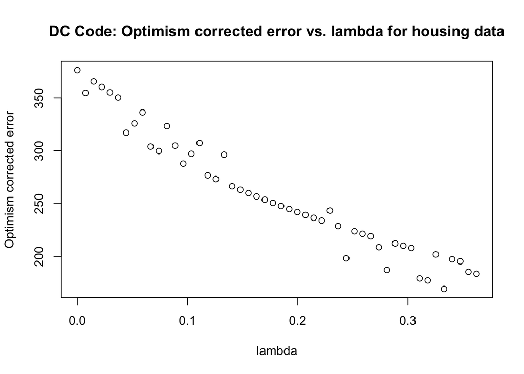

```r
temp <- composite.rpart(dat=gen.data,n.grid=50,mult=4,outvar="mdev")
plot(temp$lambdas,temp$error.lambdas,xlab="lambda",ylab="Optimism corrected error",
     main="DC Code: Optimism corrected error vs. lambda for housing data")
```

The min of which is$ 0.3326972$.

The corresponding tree is:

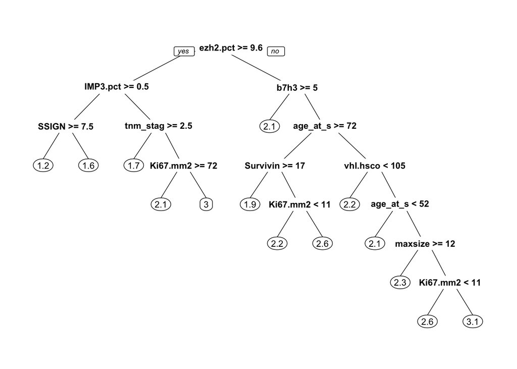

With corresponding resubstitution estimate of $716.1290728$.

### Third’s Code

```r
composite.rpart.thirds <- function(dat,n.grid=20,mult=2,outvar="Y",verbose=FALSE)
{
  n <- nrow(dat)
  which.outcome <- which(colnames(dat)==outvar)
  colnames(dat)[which.outcome] <- "outvar.aim2"

  #Split into learning and evaluation sets
  nlearn <- round(n/3)
  ndisc <- round(n/3)
  neval <- n-nlearn-ndisc
  samp <- sample(1:n,n,replace=FALSE)

#  matrix.lambdas <- matrix(0,3,n.grid)
  error.lambdas <- matrix(0,3,n.grid)

                                        # Choose one set of lambdas in the beginning

  n1 <- round(n/2)
  n2 <- n-n1
  samp2 <- sample(1:n,n,replace=FALSE)
  which.n1 <- 1:n1
  which.n2 <- (n1+1):n
  wn1 <- sort(samp[which.n1])
  wn2 <- sort(samp[which.n2])
  n1.dat <- dat[wn1,]
  n2.dat <- dat[wn2,]

  fit.rf.n1 <- randomForest(outvar.aim2 ~ .,data = n1.dat) # Fit RF with learning set
  predict.rf.n2 <- predict(fit.rf.n1,newdata=n2.dat,predict.all=TRUE) #  $\widehat{Z}_{1i}$
  mean.n2 <- mean(n2.dat$outvar.aim2) # $\mu_{Z_1}$
  var.n2 <- var(n2.dat$outvar.aim2) # $\sigma^2_{Z_1}$
  zbarhat <- mean(predict.rf.n2$aggregate) # $ \bar{\hat{Z_1}}$
  var.z1s <-  apply(predict.rf.n2$individual,1,var) # $\sigma^2_{\hat{Z_1i}}$
  alphas <- 1/var.z1s # $\alpha_i$
                                        # alphas <- alphas/sum(alphas)
  alphabar <- mean(alphas) # \bar{\alpha}$
  lambda <- var.n2/(ndisc*alphabar*(mean.n2-zbarhat)^2) #with-in node #choice of \lambda
  lambdas <- seq(0,mult*lambda,length.out=n.grid)  # list of possible lambdas

  for(i in 1:3)
  {
      if(i==1)
      {
          which.learn <- 1:nlearn
          which.disc <- (nlearn+1):(nlearn+ndisc)
          which.eval <- (nlearn+ndisc+1):n
      }
      else if(i==2)
      {
          which.learn <- (nlearn+1):(nlearn+ndisc)
          which.disc <- (nlearn+ndisc+1):n
          which.eval <- 1:nlearn
      }
      else
      {
          which.learn <- (nlearn+ndisc+1):n
          which.disc <- 1:nlearn
          which.eval <- (nlearn+1):(nlearn+ndisc)
      }

      wlearn <- sort(samp[which.learn])
      wdisc <- sort(samp[which.disc])
      weval <- sort(samp[which.eval])

      learning.dat <- dat[wlearn,]
      discovery.dat <- dat[wdisc,]
      evaluation.dat <- dat[weval,]

      fit.rf.learning <- randomForest(outvar.aim2 ~ .,data = learning.dat) # Fit RF with learning set
      predict.rf.discovery <- predict(fit.rf.learning,newdata=discovery.dat,predict.all=TRUE) #  $\widehat{Z}_{1i}$
      mean.discovery <- mean(discovery.dat$outvar.aim2) # $\mu_{Z_1}$
      var.discovery <- var(discovery.dat$outvar.aim2) # $\sigma^2_{Z_1}$
      zbarhat <- mean(predict.rf.discovery$aggregate) # $ \bar{\hat{Z_1}}$
      var.z1s <-  apply(predict.rf.discovery$individual,1,var) # $\sigma^2_{\hat{Z_1i}}$
      alphas <- 1/var.z1s # $\alpha_i$
                                        # alphas <- alphas/sum(alphas)
      alphabar <- mean(alphas) # \bar{\alpha}$
#      lambda <- var.discovery/(ndisc*alphabar*(mean.discovery-zbarhat)^2) #with-in node
#                                        #choice of \lambda
#      lambdas <- seq(0,mult*lambda,length.out=n.grid)  # list of possible lambdas

      if(verbose)
      {
          print(paste("zbarhat =",zbarhat))
          print(paste("mean.discovery =",mean.discovery))
          print(paste("alphabar =",alphabar))
          print(paste("neval =",neval))
          print(paste("var.discovery =",var.discovery))
          print(paste("lambda =",lambda))
          print(paste("nlearn =",nlearn))
          print(paste("ndisc =",ndisc))
      }
 #     lambdas <- seq(0,mult*lambda,length.out=n.grid)  # list of possible lambdas
 #     matrix.lambdas[i,] <- lambdas
      fits <- vector("list",n.grid)
      pruneds <- vector("list",n.grid)
      predictions <- vector("list",n.grid)
      use.dat<-discovery.dat
                                        # To get the err(\lambda) - uncorrected - currently equation 11
      for(j in 1:n.grid)
      {
          new.lambda <- lambdas[j]
          new.denom <- (1+alphas*new.lambda)
          ri <- 1/new.denom
          ci <- ri*use.dat$outvar.aim2 + (1-ri)*predict.rf.discovery$aggregate
          new.use.dat <- use.dat
          new.use.dat$outvar.aim2 <- ci
          current.fit <- rpart(outvar.aim2 ~ .,data = new.use.dat)
          min.CP<-current.fit$cptable[which(current.fit$cptable[,4]==min(current.fit$cptable[,4])),1][1]
          current.fit.pruned<-prune(current.fit,cp=min.CP)
          predicted.fit <- predict(object=current.fit.pruned, newdata=evaluation.dat)
          error.lambdas[i,j] <- sum((evaluation.dat$outvar.aim2-predicted.fit)^2)
          fits[[j]] <- current.fit
          pruneds[[j]] <- current.fit.pruned
          predictions[[j]] <- predicted.fit
      }
  }
  sum.lambdas <- apply(error.lambdas,2,sum)
  top.lambda <- order(sum.lambdas)[1]
  best.lambda <- lambdas[top.lambda]
  fit.rf.all <- randomForest(outvar.aim2 ~ .,data = dat) # Fit RF with learning set
  predict.rf.all <- predict(fit.rf.learning,newdata=dat,predict.all=TRUE) #  $\widehat{Z}_{1i}$
  var.all <-  apply(predict.rf.all$individual,1,var) # $\sigma^2_{\hat{Z_1i}}$
  alphas.all <- 1/var.all
#  alphas.all <- alphas.all/sum(alphas.all)
  new.denom <- (1+alphas.all*best.lambda)
  ri <- 1/new.denom
  ci <- ri*dat$outvar.aim2 + (1-ri)*predict(fit.rf.learning,newdata=dat)
  dat$outvar.aim2 <- ci
  current.fit <- rpart(outvar.aim2 ~ .,data = dat)
  min.CP<-current.fit$cptable[which(current.fit$cptable[,4]==min(current.fit$cptable[,4])),1][1]
  current.fit.pruned<-prune(current.fit,cp=min.CP)
# current.fit.pruned is the final model
  list(best.lambda=best.lambda,lambda=lambda,lambdas=lambdas,error.lambdas=error.lambdas,fits=fits,pruneds=pruneds,predictions=predictions,current.fit=current.fit,current.fit.pruned=current.fit.pruned,alphas=alphas.all,alphas.lambda=alphas.all*best.lambda,ri=ri)
}
```

```r
temp2 <- composite.rpart.thirds(dat=gen.data,n.grid=100,mult=4,outvar="mdev")

  #plot(temp2$lambdas,temp2$error.lambdas,xlab="lambda",ylab="Optimism corrected error",
  #     main="Thirds: Optimism corrected error vs. lambda for housing data")
```

The corresponding tree is:

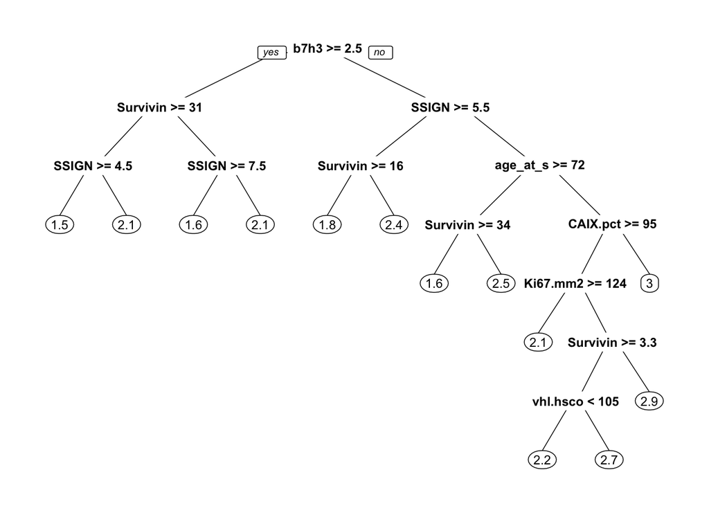

With corresponding resubstitution estimate of $676.1537618$.

### Rob’s Code

Comments from Rob:

One modification that I did make is to use a log-spline density estimator in place of a normal distribution for carrying out the parametric bootstrap; you need the package logspline from CRAN. This does quite a good job in capturing and then subsequently simulating data with a response profile that looks similar to the original (definitely better than the normal). But unfortunately the cross-validation curve that gets generated doesn’t really differ a lot from that obtained using the normal distribution. Not really sure what is going on here.

The leave one out CV procedure has a clearly defined minimum for lambda for the housing data, at least over the range of lambdas I considered. The parametric bootstrap gives a local min that is in the same ballpark. I haven’t looked at the corresponding composite response tree built using lambdas in this range.

If you run it, it will take a while (3-5 mins) since it does both LOO and parametric bootstrap CV (with 1000 replicates – 10 is way too small).

Two other things:

- I don’t think the original method for calculating the “root node” lambda is correct for the composite methods so right now we are stuck using a grid.
- The composite response seems to have some potential to create heteroscedasticity – I think low variance predictions will generate composite responses with smaller variances compared to those with high variance predictions, for example. There has been some work on studying the performance of trees in this setting but I don’t know what kind of software might be out there to fit such trees.

```r
# R version of Matlab function 'repmat'. E.g., if given a
# vector 'X' of length 'k', then repmat(X,1,n) will give the
# k x n matrix where each matrix column is a copy of X.


repmat = function(X, m, n) {
  if (is.vector(X))
    X = matrix(X, length(X), 1)
  mx = dim(X)[1]
  nx = dim(X)[2]
  return(matrix(t(matrix(X, mx, nx * n)), mx * m, nx * n, byrow = T))
}

# Use leave-one-out CV (LOO)
CVcorrected.lambda <- function(dat, lambdas, model, predicted.values,
                               alphas) {
  n1 <- nrow(dat)
  p <- ncol(dat)
  n.lambdas <- length(lambdas)
  cilambda <- matrix(0, n1, n.lambdas)

  for (b in 1:n1) {
    # create new LOO dataset that deletes bth observation
    new.dat <- dat[-b, ]

    # for bth LOO dataset, loop over lambda
    for (j in 1:n.lambdas) {
      # derive modified response
      new.lambda <- lambdas[j]
      ri <- 1/(1 + alphas[-b] * new.lambda)
      ci <- ri * new.dat$outvar.aim2 + (1 - ri) * predicted.values[-b]

      # create modified LOO dataset
      use.dat = new.dat
      use.dat$outvar.aim2 = ci

      # fit model to modified LOO dataset
      final.fit <- rpart(outvar.aim2 ~ ., data = use.dat)

      ####################################################### prune this fit
      xgroup <- rep(1:10, length = nrow(use.dat))
      xfit <- xpred.rpart(final.fit, xgroup)

      # here -- calculates error using original bootstrap response
      # (new.dat) and not use.dat (weighted response)
      xerror <- colMeans((xfit - new.dat$outvar.aim2)^2)

      ff = which(xerror == min(xerror))[1]
      min.CP <- final.fit$cptable[ff, 1]
      final.fit.pruned <- prune(final.fit, cp = min.CP)
      #######################################################


      # calculate the predicted value for each subject in dat from
      # new LOO model built using dat[-b,]
      bigMhat <- predict(object = final.fit.pruned, newdata = dat)

      # get Zb - tree(-b,Wb) for the bth LOO at lambda = lambda[j]
      # and square the result
      diffpred = (dat$outvar.aim2 - bigMhat)[b]
      cilambda[b, j] = diffpred^2
    }
  }
  return(apply(cilambda, 2, sum))
}


# parametric bootstrap - this has been modified from Adam's
# original version

corrected.lambda.LSD <- function(dat, lambdas, list.object, model,
                             predicted.values, alphas, n.boot = 10) {
  n1 <- nrow(dat)
  p <- ncol(dat)
  n.lambdas <- length(lambdas)
  cilambda <- matrix(0, n1, n.lambdas)

  # bootstrap the data - generate new 'Z's about \hat{Z}

  # note: the code below is equivalent but faster than original
  # bootstrap code that used normal errors sigmahat <-
  # sqrt(sum((dat$outvar.aim2-predicted.values)^2)/n1) boot.dat
  # =
  # matrix(rnorm(n.boot*n1,mean=predicted.values,sd=sigmahat),n1,n.boot)
  # boot.mean <- apply(boot.dat,1,mean) boot.residual =
  # boot.dat-boot.mean

  # here, use a nonparametric density estimator for the errors
  # 'Zi-\hat{Zi}' and then generate bootstrapped Z by adding
  # random error to \hat{Zi}
  yy = dat$outvar.aim2 - predicted.values
  fit = logspline(yy)
  booterr.dat = matrix(rlogspline(n.boot * n1, fit), n1, n.boot)
  boot.dat = repmat(predicted.values, 1, n.boot) + booterr.dat
  boot.mean <- repmat(as.vector(apply(boot.dat, 1, mean)),
                      1, n.boot)
  boot.residual = boot.dat - boot.mean
  for (b in 1:n.boot) {
    new.dat <- dat
    new.dat$outvar.aim2 <- boot.dat[, b]

    for (j in 1:n.lambdas) {
      new.lambda <- lambdas[j]
      ri <- 1/(1 + alphas * new.lambda)
      ci <- ri * new.dat$outvar.aim2 + (1 - ri) * predicted.values
      use.dat = new.dat
      use.dat$outvar.aim2 = ci

      # fit model to bootstrapped weighted response
      final.fit <- rpart(outvar.aim2 ~ ., data = use.dat)

      ####################################################### prune the bootstrap fit
      xgroup <- rep(1:10, length = nrow(use.dat))
      xfit <- xpred.rpart(final.fit, xgroup)

      # here -- calculates error using original bootstrap response
      # (new.dat) and not use.dat (weighted response)
      xerror <- colMeans((xfit - new.dat$outvar.aim2)^2)

      ff = which(xerror == min(xerror))[1]
      min.CP <- final.fit$cptable[ff, 1]
      final.fit.pruned <- prune(final.fit, cp = min.CP)
      #######################################################

      # calculate the predicted value for each subject in use.dat;
      # note that it does not matter whether use.dat or new.dat is
      # used here since the response is not used in deriving model
      # prediction
      bigMhat <- predict(object = final.fit.pruned, newdata = use.dat)

      # for lambda=lambda[j], add bootstrap contributions to
      # covariance penalty from bth sample. The boot.residual is
      # the bootstrapped response, not weighted response. Also,
      # note that this is numerically equivalent to calculation
      # that replaces 'bigMhat' with 'bigMhat-predicted.values'

      cilambda[, j] <- cilambda[, j] + bigMhat * boot.residual[,
                                                               b]

    }
  }
  cilambda <- cilambda/(n.boot - 1)
  return(2 * apply(cilambda, 2, sum))
}

composite.rpart.Grid = function(dat, n.grid = 20, mult = 1, uplim = 10,
                           outvar = "Y", prop.learning = 0.5) {

  n <- nrow(dat)
  which.outcome <- which(colnames(dat) == outvar)
  colnames(dat)[which.outcome] <- "outvar.aim2"

  # Split into learning and evaluation sets
  nlearn <- round(prop.learning * n)
  neval <- n - nlearn
  samp <- sample(1:n, n, replace = FALSE)
  wlearn <- sort(samp[1:nlearn])
  weval <- sort(samp[(nlearn + 1):n])
  learning.dat <- dat[wlearn, ]
  evaluation.dat <- dat[weval, ]

  # use learning set to derive RF predictions
  fit.rf.learning <- randomForest(outvar.aim2 ~ ., data = learning.dat,
                                  ntree = 1000)
  predict.rf.evaluation <- predict(fit.rf.learning, newdata = evaluation.dat,
                                   predict.all = TRUE)

  # mean, variance of Z's in evaluation set
  mean.evaluation <- mean(evaluation.dat$outvar.aim2)  # $\mu_{Z_1}$
  var.evaluation <- var(evaluation.dat$outvar.aim2)  # $\sigma^2_{Z_1}$

  # mean, variance of RF predictions for evaluation set
  zbarhat <- mean(predict.rf.evaluation$aggregate)  # $ \bar{\hat{Z_1}}$
  var.z1s <- apply(predict.rf.evaluation$individual, 1, var)  # $\sigma^2_{\hat{Z_1i}}$

  # Hard to know how to chooose. Need to think about objective.
  # But sensible choice in that high variance predictions would
  # get lower weight
  alphas <- 1/var.z1s
  # alphas = rep(1,length(var.z1s))

  # 'optimal' 'root node' lambda for specified alphas - not
  # really relevant here since calculated using a different
  # objective. Could revisit this calculation. alphabar <-
  # mean(alphas) # \bar{\alpha}$ lambda <-
  # var.evaluation/(neval*alphabar*(mean.evaluation-zbarhat)^2)
  # print(paste('lambda =',lambda))

  # grid of lambda values
  lambdas <- seq(0, uplim, length.out = n.grid)  # list of possible lambdas
  n.lambdas <- length(lambdas)  #length of list

  error.lambdas <- rep(0, length(lambdas))
  errorU.lambdas <- rep(0, length(lambdas))
  fits <- vector("list", n.lambdas)
  predictions <- vector("list", n.lambdas)

  use.dat <- evaluation.dat

  for (j in 1:n.lambdas) {

    new.lambda <- lambdas[j]
    new.denom <- (1 + alphas * new.lambda)
    ri <- 1/new.denom

    # weighted response calculation
    ci <- ri * use.dat$outvar.aim2 + (1 - ri) * predict.rf.evaluation$aggregate

    # build tree using dataset that employs weighted response
    new.use.dat <- use.dat
    new.use.dat$outvar.aim2 <- ci
    current.fit <- rpart(outvar.aim2 ~ ., data = new.use.dat)

    # prune that tree using manual CV
    min.CP <- current.fit$cptable[which(current.fit$cptable[,
                                                            4] == min(current.fit$cptable[, 4])), 1][1]
    current.fit.pruned <- prune(current.fit, cp = min.CP)

    # derive predicted outcomes for each observation in that
    # dataset
    predicted.fit <- predict(object = current.fit.pruned,
                             data = new.use.dat)

    # calculate 'apparent error' using 'ci' as response
    error.lambdas[j] <- sum((new.use.dat$outvar.aim2 - predicted.fit)^2)

    # calculate 'apparent error' using actual response
    errorU.lambdas[j] <- sum((use.dat$outvar.aim2 - predicted.fit)^2)


    fits[[j]] <- current.fit
    predictions[[j]] <- predicted.fit
  }

  CVError.lambdas <- CVcorrected.lambda(dat = evaluation.dat,
                                        lambdas = lambdas, model = fit.rf.learning, predicted.values = predict.rf.evaluation$aggregate,
                                        alphas = alphas)

  Error.lambdas <- errorU.lambdas
  optimism <- corrected.lambda.LSD(dat = evaluation.dat, lambdas = lambdas,
                               list.object = aim2.list, model = fit.rf.learning, predicted.values = predict.rf.evaluation$aggregate,
                               alphas = alphas, n.boot = 1000)
  Error.lambdas <- Error.lambdas + optimism

  list(lambdas = lambdas, error.lambdas = error.lambdas, errorU.lambdas = errorU.lambdas,
       Error.lambdas = Error.lambdas, fits = fits, predictions = predictions,
       optimism = optimism, CVError.lambdas = CVError.lambdas)
}
```

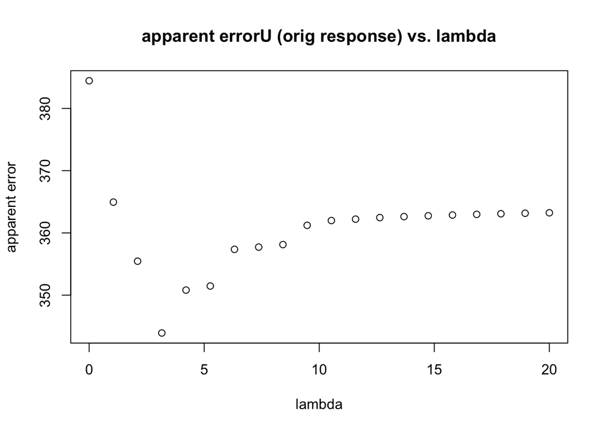

```r
temp3 <- composite.rpart.Grid(dat = gen.data, n.grid = 20, mult = 1,
                              uplim = 20, outvar = "mdev", prop.learning = 0.5)


plot(temp3$lambdas, temp3$errorU.lambdas, xlab = "lambda",
     ylab = "apparent error", main = "apparent errorU (orig response) vs. lambda")
```

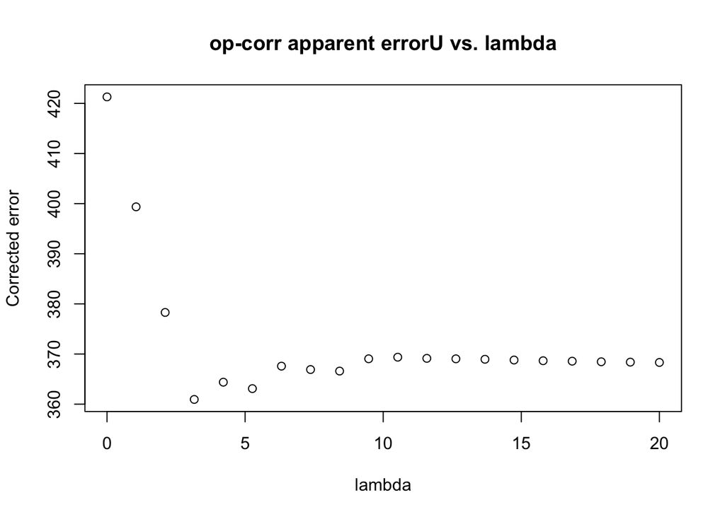

```r
plot(temp3$lambdas, temp3$Error.lambdas, xlab = "lambda", ylab = "Corrected error",
     main = "op-corr apparent errorU vs. lambda")
```

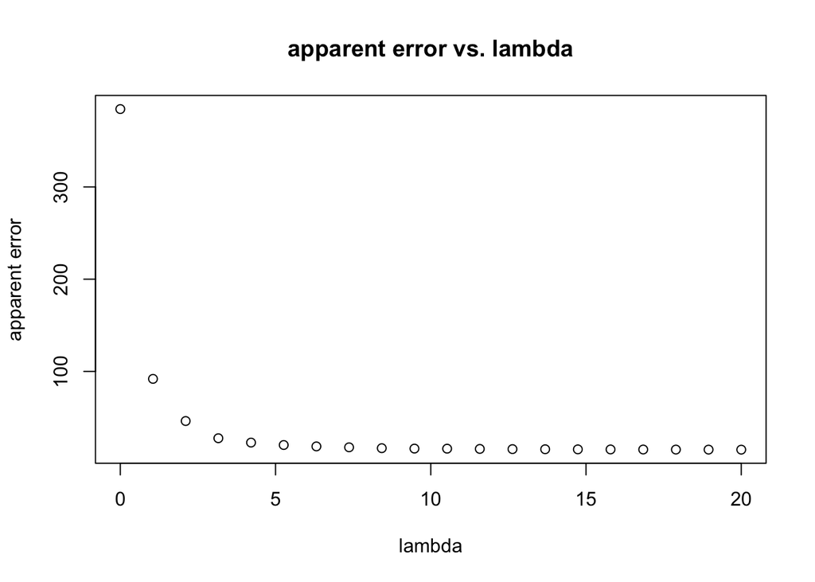

```r
plot(temp3$lambdas, temp3$error.lambdas, xlab = "lambda", ylab = "apparent error",
     main = "apparent error vs. lambda")
```

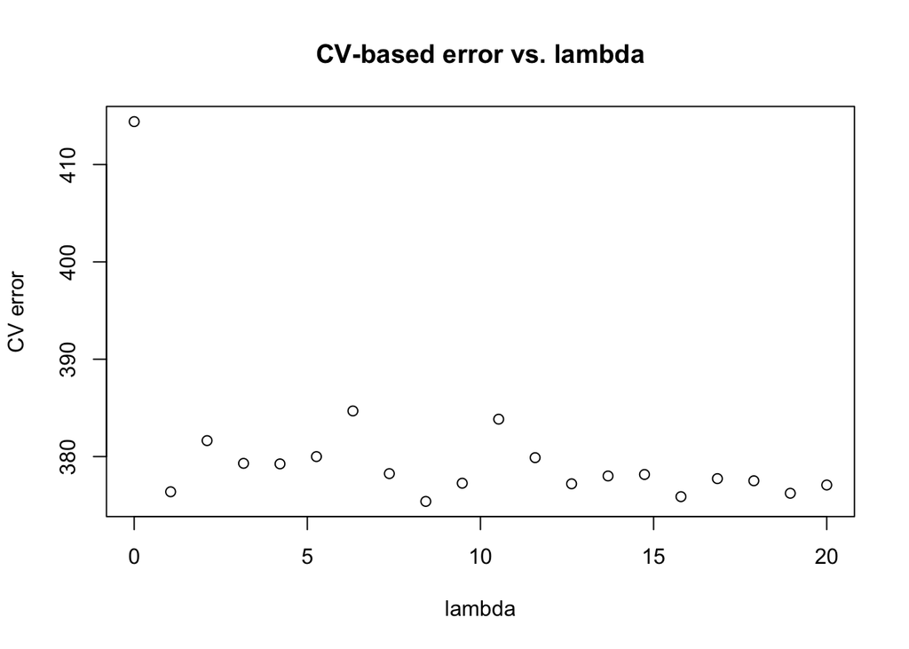

```r
plot(temp3$lambdas, temp3$CVError.lambdas, xlab = "lambda",
     ylab = "CV error", main = "CV-based error vs. lambda")
```

The corresponding tree is with CVError is:

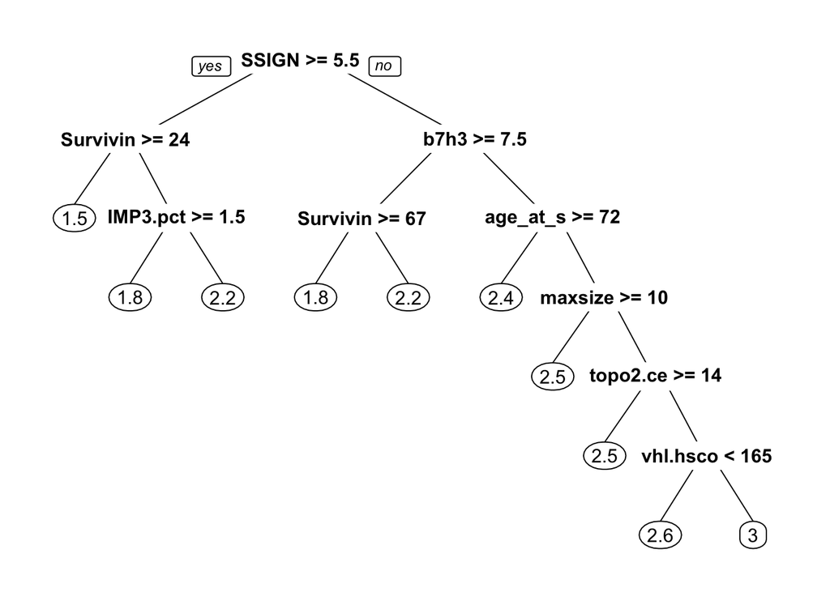

With corresponding resubstitution estimate of $721.5657933$.

The corresponding tree is with Error + Optimism is:

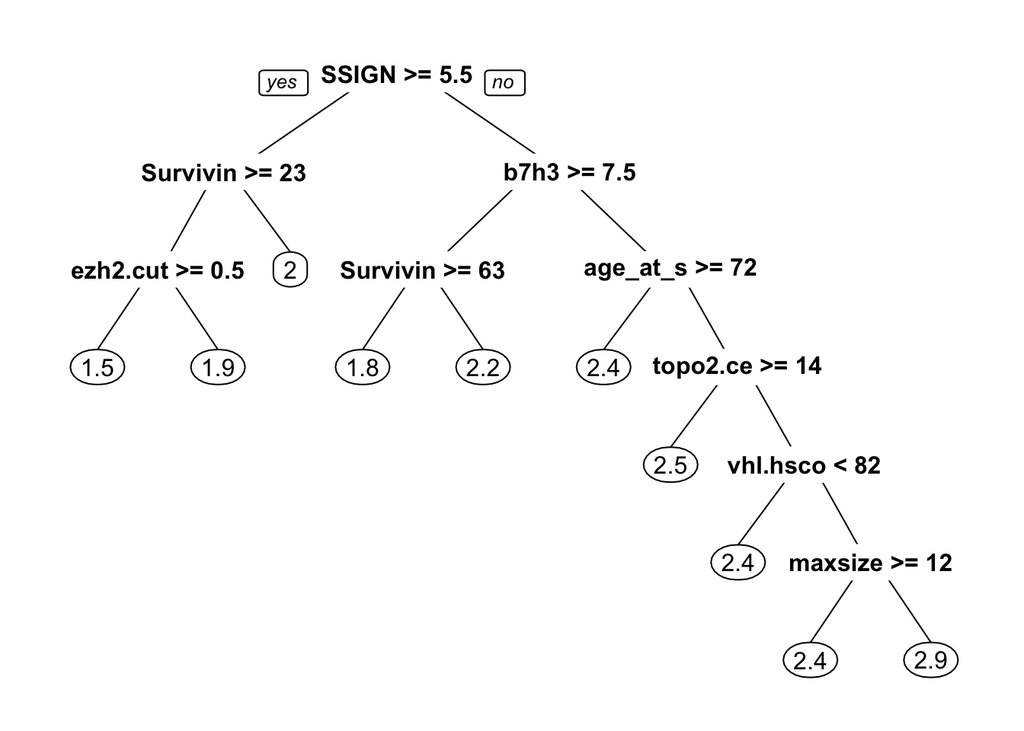

With corresponding resubstitution estimate of $712.1207353$.